# 01-pres-exploration

Ana Olsen

11/24/2020

# The Experiment

The experiment data I’m using came from a paper called [“Consistent diferences in Fitness Traits across Multiple Generations of Olympia Oysters”](https://www.nature.com/articles/s41598-018-24455-3.pdf), listed as [“F2 Puget Sound Olympia Oyster Population Structure”](https://figshare.com/articles/dataset/F2_Puget_Sound_Olympia_Oyster_Population_Structure/5975452?file=10717249) on Figshare. It was created by Katherine Silliman, Tynan Bowyer, and Steven Roberts.

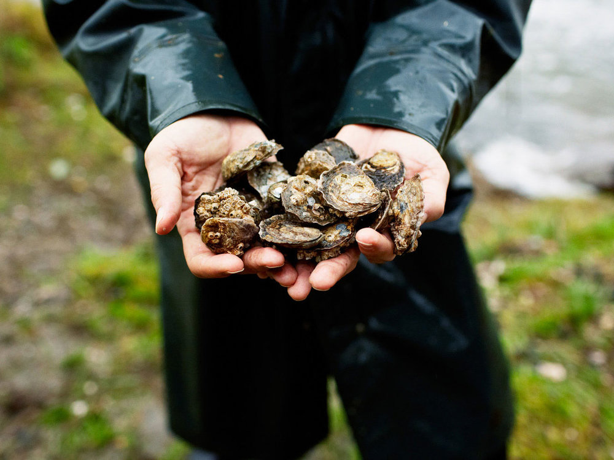

Olympia oysters (*Ostrea lurida*)

# The Data

This experiment explored the growth of populations of olympia oysters taken from different locations that were then all grown in the same lab/natural environment.

There are three relevant data tables from the experiment

1. PS_larvae: includes lengths and areas for each oyster at three time points
2. oyster_tile_size: includes size data in relation to tile grown on
3. larval_counts: includes counts of population size and number of dead oysters at each time point for each family from each population/location

# PS_Larvae Data

This is the layout of the data table used for the following scatterplots. Measurements were taken at day 0, 7 and 14 (July 1, 8, and 15, 2015).

| Sample_Name | Population | Replicate | Date | Days.after.start | Length_1 | Length_2 | Average_Length | Notes | Area_1 | Area_2 | Area | Scale | Photo_ID | Photo_File | X | X.1 | X.2 | X.3 | X.4 | X.5 |
| --- | --- | --- | --- | --- | --- | --- | --- | --- | --- | --- | --- | --- | --- | --- | --- | --- | --- | --- | --- | --- |
| D | Dabob Bay | NA | 7/1/2015 | NA | 0.1635 | 0.1693 | 0.1664 |  | 0.0168 | 0.0161 | 0.01645 | NA | 1102 | 1 | NA | NA | NA | NA | NA | NA |
| D | Dabob Bay | NA | 7/1/2015 | NA | 0.1644 | 0.1673 | 0.1659 |  | 0.0186 | 0.0187 | 0.01865 | NA | 1103 | 1 | NA | NA | NA | NA | NA | NA |
| D | Dabob Bay | NA | 7/1/2015 | NA | 0.1432 | 0.1423 | 0.1428 |  | 0.0160 | 0.0162 | 0.01610 | NA | 1103 | 2 | NA | NA | NA | NA | NA | NA |
| D | Dabob Bay | NA | 7/1/2015 | NA | 0.1534 | 0.1590 | 0.1562 |  | 0.0170 | 0.0164 | 0.01670 | NA | 1106 | 1 | NA | NA | NA | NA | NA | NA |
| D | Dabob Bay | NA | 7/1/2015 | NA | 0.1405 | 0.1340 | 0.1373 | messy | 0.0148 | 0.0141 | 0.01445 | NA | 1106 | 2 | NA | NA | NA | NA | NA | NA |
| D | Dabob Bay | NA | 7/1/2015 | NA | 0.1500 | 0.1420 | 0.1460 | blurry | 0.0150 | 0.0137 | 0.01435 | NA | 1104 | 2 | NA | NA | NA | NA | NA | NA |

# Average Shell Length over Time in 3 Populations

I took the mean of the average length of each oyster for each of the three populations/locations, Daobob Bay, Fidalgo Bay, and Oyster Bay. That led to three data points over time for each population since they were measured every 7 days. To make the dates work correctly I created a string of the days after start for each mean.

```r
#average length for each population
avg_l_popul <- summarize(popul_days, mean_l = mean(Average_Length), na.rm = TRUE)
#added column for days after start
avg_l_popul$Days = c(0, 14, 7, 0, 14, 7, 0, 14, 7)
```

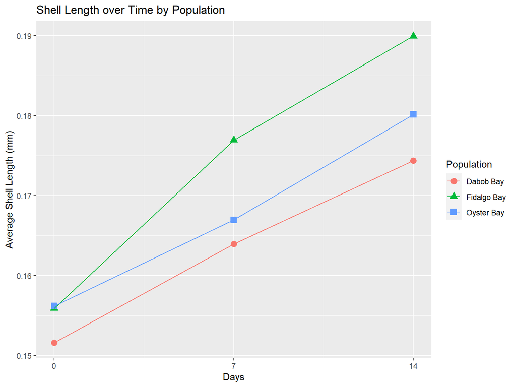

# Average Shell Area

This scatterplot shows the average area of all the oysters for each population.

I created it the same way as the one for average length, just calculated the average area instead.

The shape of the larvae makes the area smaller than the largest length. But the overall trend is the same, so the oysters are a consistent shape across population, but they grow at different rates.

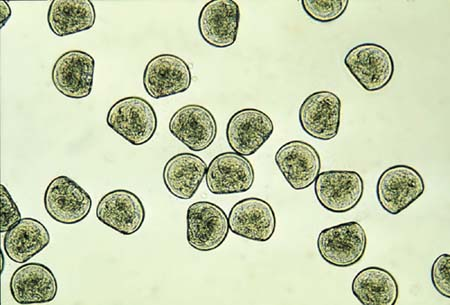

Oyster larvae

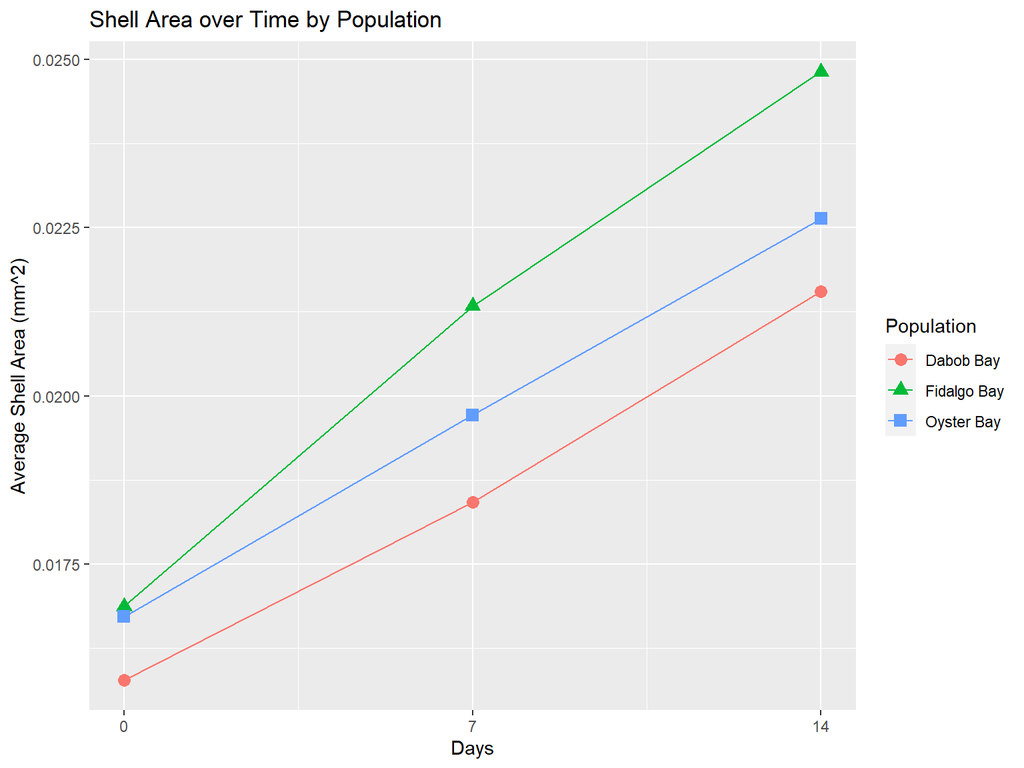

# Population Reproduction Over Time

Fidalgo Bay had a much lower spawn number, but they all still had similar trends. This is interesting since Fidalgo Bay also had the largest growth rates.

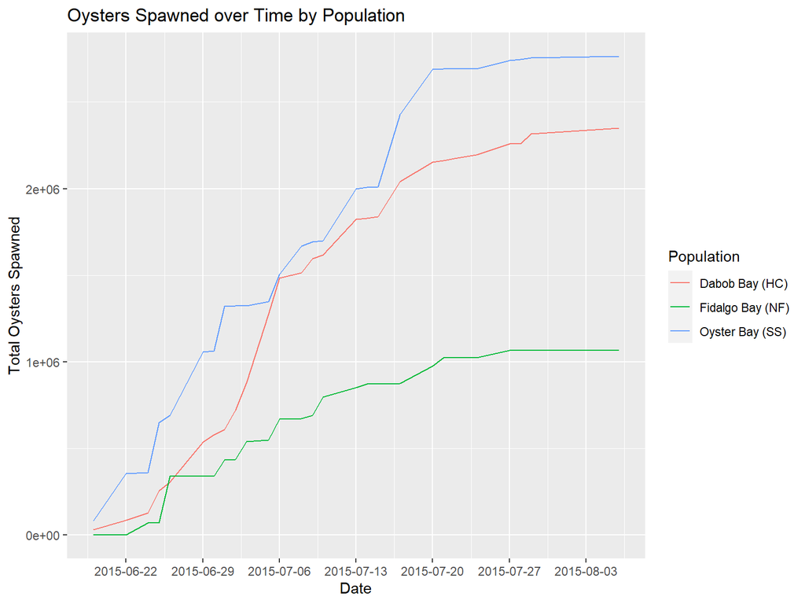

# What I Learned

- Firsthand how important it is to have an understandable and usable data table
- How to alter those tables for what I need
- How to display better graphics
- How to interpret data starting from Figshare
- Develop a good process for coding and creating a presentation in RStudio
- How to use GitHub for collaboration